# Homework 08

Author

Shushi Meng

## Question 1: Boundary and margin

For each observation I used `f(x) = 0.8x1 + 0.6x2`. Because the coefficient vector has length 1, the distance to the boundary is `|f(x)|`. I compared `y f(x)` with 1: below 1 is inside, equal to 1 is on, and above 1 is beyond the margin.

| Observation | Distance to boundary | y f(x) | Position |
| --- | --- | --- | --- |
| 1 | 1.00 | 1.00 | on |
| 2 | 1.35 | 1.35 | beyond |
| 3 | 1.50 | 1.50 | beyond |
| 4 | 1.70 | 1.70 | beyond |
| 5 | 1.90 | 1.90 | beyond |
| 6 | 2.20 | 2.20 | beyond |
| 7 | 2.40 | 2.40 | beyond |
| 8 | 0.64 | 0.64 | inside |
| 9 | 0.20 | 0.20 | inside |
| 10 | 0.20 | -0.20 | inside |
| 11 | 1.00 | 1.00 | on |
| 12 | 1.30 | 1.30 | beyond |
| 13 | 1.55 | 1.55 | beyond |
| 14 | 1.75 | 1.75 | beyond |
| 15 | 1.95 | 1.95 | beyond |
| 16 | 2.15 | 2.15 | beyond |
| 17 | 2.45 | 2.45 | beyond |
| 18 | 0.64 | 0.64 | inside |
| 19 | 0.24 | 0.24 | inside |
| 20 | 0.20 | -0.20 | inside |

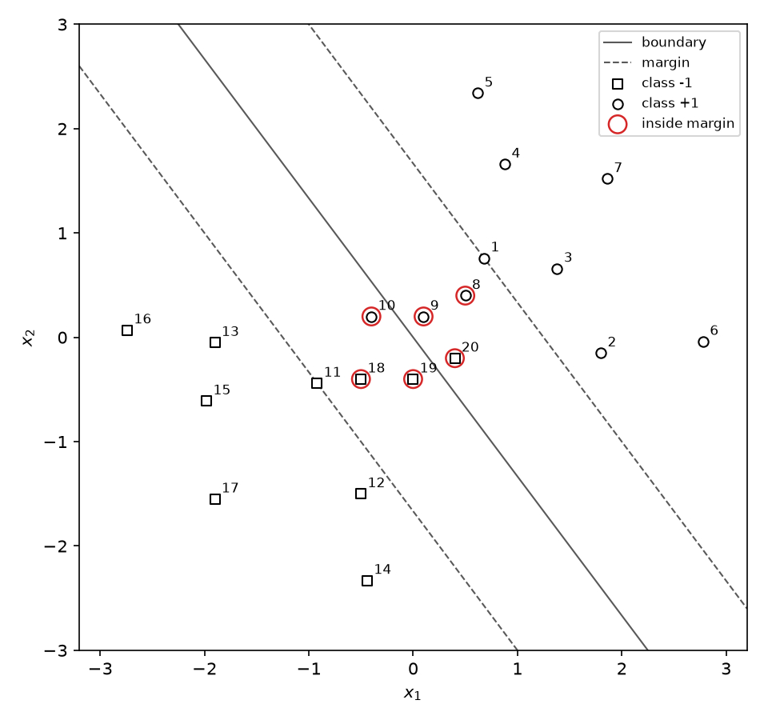

Boundary, margin lines, and numbered observations

There are **6 inside**, **2 on**, and **12 beyond** the margin. Observations **10 and 20** have `y f(x) = -0.20`, so both are misclassified. I used the given score; I did not fit a new classifier.

## Question 2: Margin in four dimensions

The coefficient vector has length `sqrt(1² + 2² + (-2)² + 4²) = 5`. I plotted each observation at `t = x·beta / 5`. In this coordinate, `f(x) = 5t - 1`, so the boundary is at `t = 0.20`.

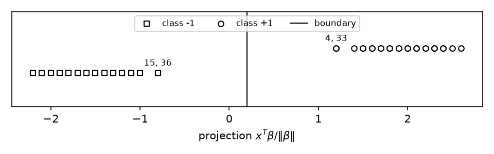

Projected observations and boundary

Observations **4, 15, 33, and 36** are closest: their absolute scores are 5, so each is `5 / 5 = 1` unit from the boundary. Thus the geometric margin is **M = 1**. The smallest functional margin `y f(x)` is 5. Dividing the entire score by 5 gives the same boundary in SVM normalization: **beta = (0.2, 0.4, -0.4, 0.8)** and **beta0 = -0.2**. The smallest new functional margin is 1.

## Question 3: Peer review of a Homework 7 skill

The skill’s seed 432 gave 323 training rows and 139 reserved test rows. Five stratified training folds were used for all candidates, with any scaling and PCA fitted within each fold. The class counts were 302 for `chd=0` and 160 for `chd=1`. There were no missing values or duplicate rows. Full candidate results and fold assignments are in the working files.

| Candidate | CV mistakes / 323 | CV error |
| --- | --- | --- |
| LDA | 85 / 323 | 0.263 |
| QDA | 92 / 323 | 0.285 |
| PCA 0.80 LDA | 84 / 323 | 0.260 |
| PCA 0.80 QDA | 91 / 323 | 0.282 |
| PCA 0.90 LDA | 81 / 323 | 0.251 |
| PCA 0.90 QDA | 89 / 323 | 0.276 |
| PCA 0.95 LDA | 82 / 323 | 0.254 |
| PCA 0.95 QDA | 94 / 323 | 0.291 |
| Blend 0.25 | 93 / 323 | 0.288 |
| Blend 0.50 | 93 / 323 | 0.288 |
| Blend 0.75 | 85 / 323 | 0.263 |

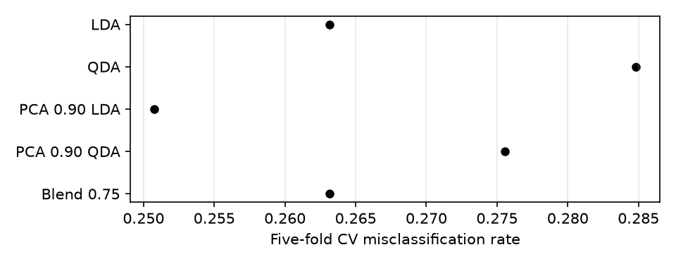

The selected **PCA (90% variance target) + LDA** retained 7 components when refitted on all training rows. Its cross-validation error was **81/323 = 0.251**. Fitted class priors were **0.653** and **0.347**; projected class-mean norms were **0.512** and **0.964**, and the projected covariance had rank **7**. On the reserved test set, it made **37/139 = 0.266** mistakes. The test confusion matrix (observed rows, predicted columns) was `[[77, 14], [23, 25]]`. No candidate failed to fit.

### Peer review

Overall, the skill was easy to follow. It kept the test set separate and produced a clear, short report. I suggest three improvements:

1. **Specify the model search more clearly.** The skill suggests PCA targets and blend weights but leaves the exact choices open. Your report selected PCA 80% + LDA (80/323 CV mistakes), while my run selected PCA 90% + LDA (81/323). A fixed default grid and saved fold assignments would make runs easier to compare.
2. **Show errors for each class.** The report’s overall test error is 26.62%, but 23 of 48 CHD cases were missed. That matters in a heart-disease example. I would require the positive-class miss rate alongside overall error.
3. **Use text for the report table.** The submitted one-page analysis is an image in the HTML file. It looks good, but its numbers cannot be selected or searched. An HTML table and text, with only the plot kept as an image, would be easier to read and reuse.

The same review is posted in [GitHub Issue #4](https://github.com/JingyiYang771/stat432-fall2026/issues/4).